# DA 101 Lec 16

29 October, 2019

## Multiple Lin Reg Continued

Single variable (ie what you’ve done so far):

$$\hat{y} = b_0 + b_1 \cdot x$$

The goal: use the indep variable x to make predictions about the dependent variable y.

For multiple regression, we still have a linear function, but now many variables:

$$\hat{y} = b_0 + b_1 \cdot x_1 + b_2 \cdot x_2 + b_3 \cdot x_3 + ... + b_n \cdot x_n$$

Why would we do this? We hope that by adding variables, we increase predictive power. Many variables ought to have more information than just one, right??

Example: iris.

```r
head(iris)
```

|  | Sepal.Length | Sepal.Width | Petal.Length | Petal.Width | Species |
| --- | --- | --- | --- | --- | --- |
| 1 | 5.1 | 3.5 | 1.4 | 0.2 | setosa |
| 2 | 4.9 | 3.0 | 1.4 | 0.2 | setosa |
| 3 | 4.7 | 3.2 | 1.3 | 0.2 | setosa |
| 4 | 4.6 | 3.1 | 1.5 | 0.2 | setosa |
| 5 | 5.0 | 3.6 | 1.4 | 0.2 | setosa |
| 6 | 5.4 | 3.9 | 1.7 | 0.4 | setosa |

Suppose we’re scientists who want to predict the sepal length. Which variable to use?

In this dataset, we’ve got 3 options for indpendent variables (doesn’t make any sense to use Species, since that’s categorical!!*)

How do they perform individually?

```r
summary(lm(iris$Sepal.Length ~ iris$Sepal.Width))
```

```
##
## Call:
## lm(formula = iris$Sepal.Length ~ iris$Sepal.Width)
##
## Residuals:
##     Min      1Q  Median      3Q     Max
## -1.5561 -0.6333 -0.1120  0.5579  2.2226
##
## Coefficients:
##                  Estimate Std. Error t value Pr(>|t|)
## (Intercept)        6.5262     0.4789   13.63   <2e-16 ***
## iris$Sepal.Width  -0.2234     0.1551   -1.44    0.152
## ---
## Signif. codes:  0 '***' 0.001 '**' 0.01 '*' 0.05 '.' 0.1 ' ' 1
##
## Residual standard error: 0.8251 on 148 degrees of freedom
## Multiple R-squared:  0.01382,    Adjusted R-squared:  0.007159
## F-statistic: 2.074 on 1 and 148 DF,  p-value: 0.1519
```

Egh, this isn’t a good model. In fact, it’s bad! R^2 is close to zero; there’s almost no explanatory power.

Next:

```r
summary(lm(iris$Sepal.Length ~ iris$Petal.Length))
```

```
##
## Call:
## lm(formula = iris$Sepal.Length ~ iris$Petal.Length)
##
## Residuals:
##      Min       1Q   Median       3Q      Max
## -1.24675 -0.29657 -0.01515  0.27676  1.00269
##
## Coefficients:
##                   Estimate Std. Error t value Pr(>|t|)
## (Intercept)        4.30660    0.07839   54.94   <2e-16 ***
## iris$Petal.Length  0.40892    0.01889   21.65   <2e-16 ***
## ---
## Signif. codes:  0 '***' 0.001 '**' 0.01 '*' 0.05 '.' 0.1 ' ' 1
##
## Residual standard error: 0.4071 on 148 degrees of freedom
## Multiple R-squared:   0.76,  Adjusted R-squared:  0.7583
## F-statistic: 468.6 on 1 and 148 DF,  p-value: < 2.2e-16
```

Ok, much better R^2. This is our favorite so far.

One more:

```r
summary(lm(iris$Sepal.Length~iris$Petal.Width))
```

```
##
## Call:
## lm(formula = iris$Sepal.Length ~ iris$Petal.Width)
##
## Residuals:
##      Min       1Q   Median       3Q      Max
## -1.38822 -0.29358 -0.04393  0.26429  1.34521
##
## Coefficients:
##                  Estimate Std. Error t value Pr(>|t|)
## (Intercept)       4.77763    0.07293   65.51   <2e-16 ***
## iris$Petal.Width  0.88858    0.05137   17.30   <2e-16 ***
## ---
## Signif. codes:  0 '***' 0.001 '**' 0.01 '*' 0.05 '.' 0.1 ' ' 1
##
## Residual standard error: 0.478 on 148 degrees of freedom
## Multiple R-squared:  0.669,  Adjusted R-squared:  0.6668
## F-statistic: 299.2 on 1 and 148 DF,  p-value: < 2.2e-16
```

Not quite as good as Petal Length, but decent.

Question: What if we combine the two? Let’s look:

```r
irisMod <- lm(iris$Sepal.Length ~ iris$Petal.Length + iris$Petal.Width)
summary(irisMod)
```

```
##
## Call:
## lm(formula = iris$Sepal.Length ~ iris$Petal.Length + iris$Petal.Width)
##
## Residuals:
##      Min       1Q   Median       3Q      Max
## -1.18534 -0.29838 -0.02763  0.28925  1.02320
##
## Coefficients:
##                   Estimate Std. Error t value Pr(>|t|)
## (Intercept)        4.19058    0.09705  43.181  < 2e-16 ***
## iris$Petal.Length  0.54178    0.06928   7.820 9.41e-13 ***
## iris$Petal.Width  -0.31955    0.16045  -1.992   0.0483 *
## ---
## Signif. codes:  0 '***' 0.001 '**' 0.01 '*' 0.05 '.' 0.1 ' ' 1
##
## Residual standard error: 0.4031 on 147 degrees of freedom
## Multiple R-squared:  0.7663, Adjusted R-squared:  0.7631
## F-statistic:   241 on 2 and 147 DF,  p-value: < 2.2e-16
```

Ok, that’s better! What about all 3?

```r
irisMod <- lm(iris$Sepal.Length ~ iris$Sepal.Width + iris$Petal.Length + iris$Petal.Width)

summary(irisMod)
```

```
##
## Call:
## lm(formula = iris$Sepal.Length ~ iris$Sepal.Width + iris$Petal.Length +
##     iris$Petal.Width)
##
## Residuals:
##      Min       1Q   Median       3Q      Max
## -0.82816 -0.21989  0.01875  0.19709  0.84570
##
## Coefficients:
##                   Estimate Std. Error t value Pr(>|t|)
## (Intercept)        1.85600    0.25078   7.401 9.85e-12 ***
## iris$Sepal.Width   0.65084    0.06665   9.765  < 2e-16 ***
## iris$Petal.Length  0.70913    0.05672  12.502  < 2e-16 ***
## iris$Petal.Width  -0.55648    0.12755  -4.363 2.41e-05 ***
## ---
## Signif. codes:  0 '***' 0.001 '**' 0.01 '*' 0.05 '.' 0.1 ' ' 1
##
## Residual standard error: 0.3145 on 146 degrees of freedom
## Multiple R-squared:  0.8586, Adjusted R-squared:  0.8557
## F-statistic: 295.5 on 3 and 146 DF,  p-value: < 2.2e-16
```

## Diagnostic Plots

Ok, we can make multi models, but what anaylysis? How good are they?

The first thing we want to do is look at residuals (just like in the single variable case), but there’s a problem: we have multiple variables!!! How can we plot the residuals? We can have 3 different x axes, doesn’t make sense!

The solution: plot the residuals against the fitted values (yhat) instead. The dimentions match up: each residual corresponds to exactly one fitted value. ALso: fitted values are a linear function of the x variables, so thus they’re closely related and make a good stand-in.

Our biggest tool: “autoplot”. It lives in a library called ggfortify.

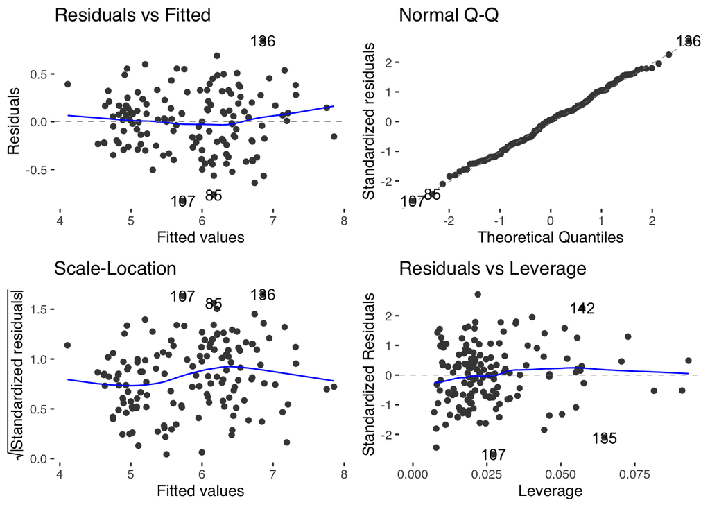

```r
library(ggfortify)

autoplot(irisMod)
```

- Upper Left: Resids vs Fitted. This is our multilinear version of the residual plot. We use fitted values on the x-axis so that we don’t worry about multiple independent variables. Interpret graph just like you did for single: variable: is there a pattern?

-Lower left: very similar to upper. BUT, here, the yvals are:

```
sqrt(  | standardized residuals  | )
```

Standardizing means “re-scaling”. Specifically:

standardized value = (x - mean)/std dev

We standardize to get everything on the same scale: shift by the mean and stretch by the standard deviation. The result has mean 0 and standard deviation 1. No matter the original data, all standardized values have the same scale.

Taking absolute value makes all residuals positive. Doing lets us focus on homoskedasticity: don’t have to worry about positive/negative. Ideally, we should see a flat trend line here, indicating that yes our data is homosked.

- Upper right: Normal qq plots test normality. If our data are normally distributed, then the points should fall on the line. Here: looks great!
- Lower right: “leverage”. Next time.

### In-class exercise:

Make the best you can with the housing dataset

```r
housingData <- read_csv("House-Sales.csv")
head(housingData)
```

| id | date | price | bedrooms | bathrooms | sqft_living | sqft_lot | improvements | floors | waterfront | view | hoa | condition | grade | sqft_above | sqft_basement | yr_built | yr_renovated | zipcode | lat | long | sqft_living15 | sqft_lot15 |
| --- | --- | --- | --- | --- | --- | --- | --- | --- | --- | --- | --- | --- | --- | --- | --- | --- | --- | --- | --- | --- | --- | --- |
| 7129300520 | 2014-10-13 | 221900 | 3 | 1.00 | 1180 | 5650 | 5 | 1 | 0 | 0 | No | Low | Low | 1180 | 0 | 1955 | 0 | 98178 | 47.5112 | -122.257 | 1340 | 5650 |
| 6414100192 | 2014-12-09 | 538000 | 3 | 2.25 | 2570 | 7242 | 8 | 2 | 0 | 0 | No | Low | Low | 2170 | 400 | 1951 | 1991 | 98125 | 47.7210 | -122.319 | 1690 | 7639 |
| 5631500400 | 2015-02-25 | 180000 | 2 | 1.00 | 770 | 10000 | 4 | 1 | 0 | 0 | No | Low | Low | 770 | 0 | 1933 | 0 | 98028 | 47.7379 | -122.233 | 2720 | 8062 |
| 2487200875 | 2014-12-09 | 604000 | 4 | 3.00 | 1960 | 5000 | 3 | 1 | 0 | 0 | No | High | Low | 1050 | 910 | 1965 | 0 | 98136 | 47.5208 | -122.393 | 1360 | 5000 |
| 1954400510 | 2015-02-18 | 510000 | 3 | 2.00 | 1680 | 8080 | 5 | 1 | 0 | 0 | Yes | Low | Medium | 1680 | 0 | 1987 | 0 | 98074 | 47.6168 | -122.045 | 1800 | 7503 |
| 7237550310 | 2014-05-12 | 1230000 | 4 | 4.50 | 5420 | 101930 | 5 | 1 | 0 | 0 | No | Low | High | 3890 | 1530 | 2001 | 0 | 98053 | 47.6561 | -122.005 | 4760 | 101930 |

Use y = price. Choose your own variables. What’s r^2? Diagnostic plot?